# Engle Road - Road data from Twitter

Winston Saunders

November 8, 2014

### Crash data analysis based on the TripCheck Twitter Feed

This analysis is based on data from the Oregon Dept of Transportation (ODOT) TripCheck feed on twitter. The feed tracks road conditions and could be useful for correlating events.

It uses a separate program to download the data from the feed (TwitterReader) available in my github repository, which stores the feed data in a local .csv file.

Current analysis is plots of a timeline of specific events and a histogram and density anlaysis.

Filtering on the crtieria: “@ Engle Road” and “crash”  
Taking complete cases reduces the number of data points to 12.

The data cover a date range from 2013-12-01 to 2014-10-15 and there were 0.2642 accidents per week.

Since the distance over which the accidents occured is 4 miles, the accident density is 3.434 accident/year/mile.

### Timline of accidents

The graph below shows a timline of accidents, with the location of the accident (measured in distance from the summit) represented by the y-axis. The positive direction is West.

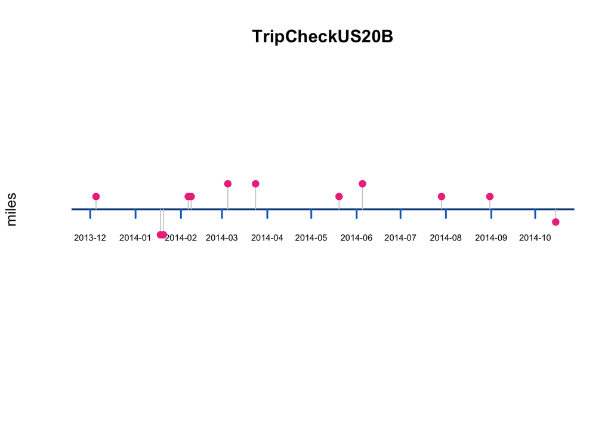

### Histogram of accident locations

This plot shows the distribution of accidents as measured by the distance from the point of reference @ Engle Road. While the number of accidents on the West side outweigh those on the wast, there appears to be a strong bias to the distribution.

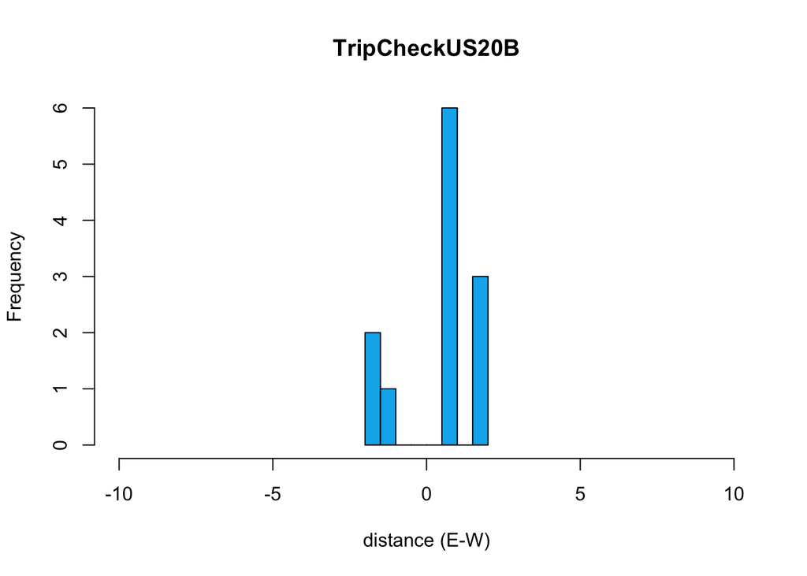

### Conclusion

This is a first analysis of this data. Will compare it to other road segments.